# Running Back Straight-Line Speed

## Loading in the data

Using tracking data, we were able to get a running back’s speed from the time of handoff to the time of first contact. Doing this allowed us to measure their straight-line speed to see their explsoivness. We then put the data into a play sheet and are able to load that in.

```r
rushing_data <<- pull_s3(paste0("analytics/projections/by_facet/", 'nfl', "/%i/rushing.csv.gz"), season_start = 2017, season_end = 2020)

play_speed_all_18 <- read.csv("~/tracking-pff/play-speed-year/play_speed_all_18.csv")
play_speed_all_19 <- read.csv("~/tracking-pff/play-speed-year/play_speed_all_19.csv")
play_speed_all_20 <- read.csv("~/tracking-pff/play-speed-year/play_speed_all_20.csv")

play_speed_all <- rbind(play_speed_all_18, play_speed_all_19, play_speed_all_20)

play_speed_all <- play_speed_all %>%
  dplyr::select(gameid, playid, player, avg_speed, seconds_before_contact, ybc)
```

## Exploratory data analysis

```r
round(summary(lm(ybc ~ avg_speed, data = play_speed_all))$r.squared, 2)
```

```
## [1] 0.15
```

```r
round(summary(lm(ybc ~ seconds_before_contact, data = play_speed_all))$r.squared, 2)
```

[output not shown]

```r
summary(lm(ybc ~ (avg_speed + seconds_before_contact)^2, data = play_speed_all))
```

```
##
## Call:
## lm(formula = ybc ~ (avg_speed + seconds_before_contact)^2, data = play_speed_all)
##
## Residuals:
##     Min      1Q  Median      3Q     Max
## -38.274  -1.361   0.127   1.356  64.915
##
## Coefficients:
##                                  Estimate Std. Error t value Pr(>|t|)
## (Intercept)                       1.00598    0.16686   6.029 1.67e-09 ***
## avg_speed                        -0.60902    0.03130 -19.460  < 2e-16 ***
## seconds_before_contact           -1.07754    0.08096 -13.310  < 2e-16 ***
## avg_speed:seconds_before_contact  0.56242    0.01311  42.909  < 2e-16 ***
## ---
## Signif. codes:  0 '***' 0.001 '**' 0.01 '*' 0.05 '.' 0.1 ' ' 1
##
## Residual standard error: 3.173 on 31242 degrees of freedom
## Multiple R-squared:  0.3862, Adjusted R-squared:  0.3861
## F-statistic:  6552 on 3 and 31242 DF,  p-value: < 2.2e-16
```

We can look at the plots of these:

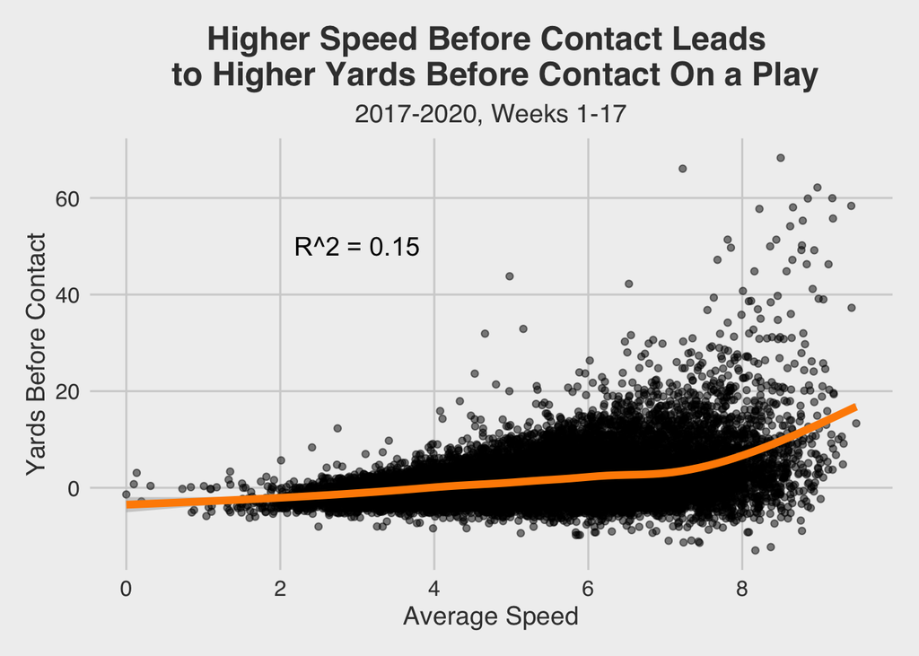

The greater effect is the amount of seconds before contact but both are meaningful for determining yards before contact.

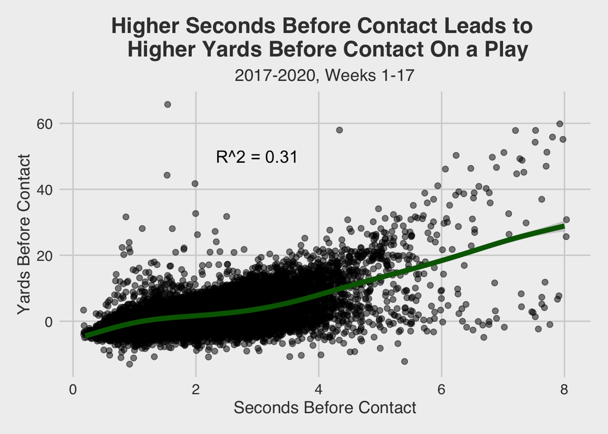

## What Influences Speed

Not all speeds are built the same. Based on down, distance, box defenders, yardline and run scheme speed can change for the average running back.

First we look at down and distance.

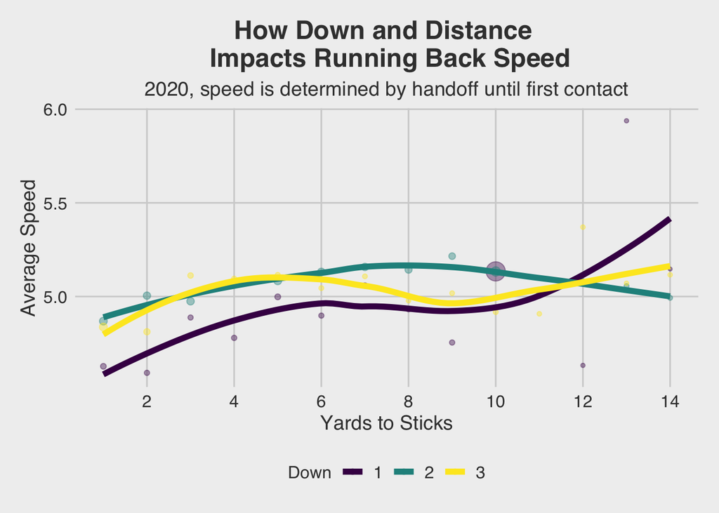

Next we can take a look at yardline and box defenders

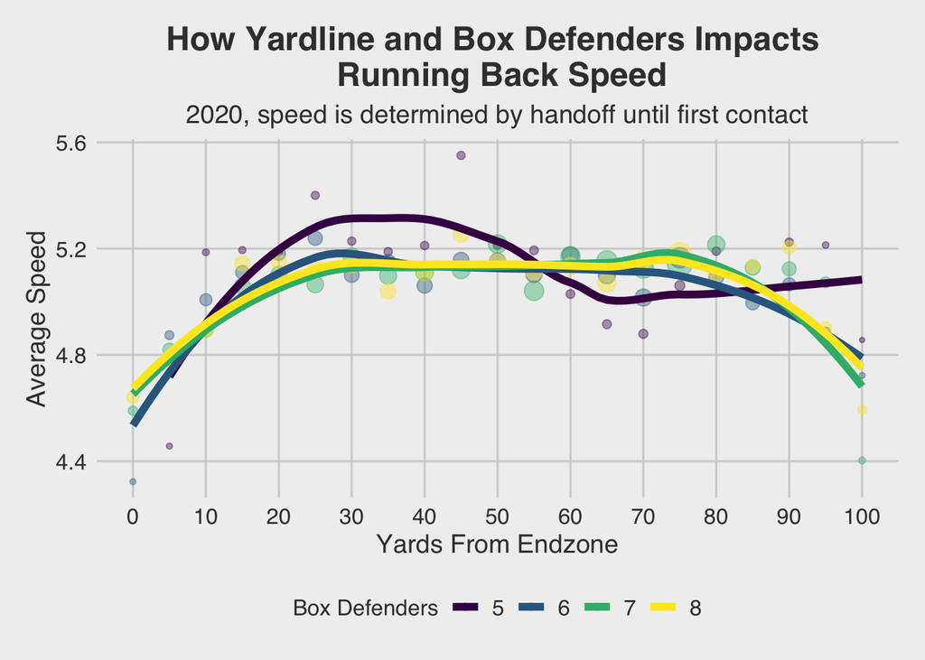

Most importantly, we can look at how different run concepts impact speed.

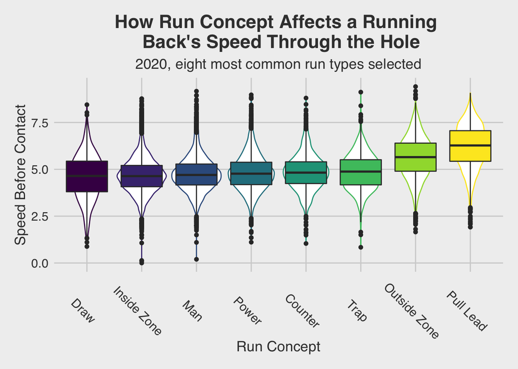

## Straight-Line Speed Over Expected (SSOE)

To adjust for all the factors listed earlier, we can use an xgboost model to created straight-line speed over expected, which is better at predicting yards before contact and more predictive than of next year’s yards before contact (YBC).

[output not shown]

[output not shown]

```r
round(summary(lm(next_ybc ~ avg_ssoe, data = speed_season_stats))$r.squared, 2)
```

```
## [1] 0.1
```

```r
round(summary(lm(next_ybc ~ exp_speed, data = speed_season_stats))$r.squared, 2)
```

```
## [1] 0.01
```

```r
round(summary(lm(next_ybc ~ avg_speed, data = speed_season_stats))$r.squared, 2)
```

```
## [1] 0.04
```

```r
round(summary(lm(next_ybc ~ avg_ybc, data = speed_season_stats))$r.squared, 2)
```

```
## [1] 0.02
```

Now that we’ve established what speed over expected can be used for, we can graph how it impacts yards before contact from 2018 to 2020.

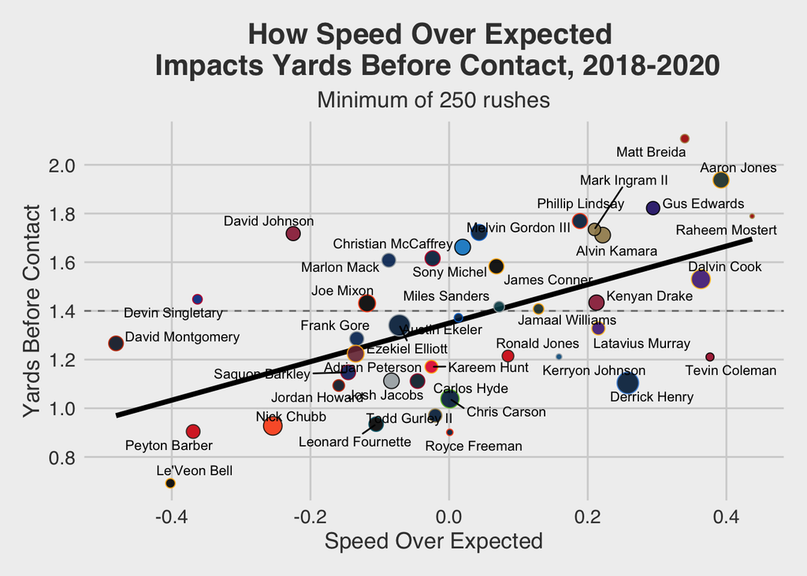

Looking at 2018 through 2020 is interesting, but focusing on just this past year is intriguing too

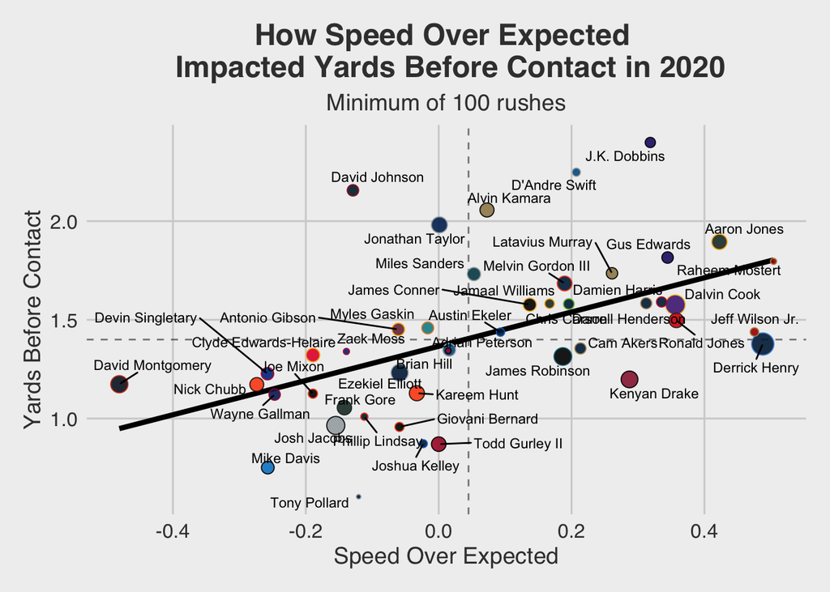

We can also look at it froma team level

[figure not shown]